# Hierarchical Bayes: panel tastes, product effects, and entry

choicer’s hierarchical Bayesian models put random effects at the two levels where applied demand work actually needs them. For person $i$ facing alternative $j$ in choice situation $t$,

$$U_{ijt} = x_{ijt}'\beta_i + \delta_j
+ \varepsilon_{ijt},
\qquad \beta_i \sim N(b, W),
\qquad \delta_j = z_j'\theta + \xi_j, \quad \xi_j \sim N(0,
\sigma_d^2).$$

- **Respondent level.** Each person carries one taste vector $\beta_i$ across all of their choice situations. This is the genuine *panel* mixed logit: by contrast, `run_mxlogit()` maximizes a cross-sectional simulated likelihood in which every choice situation is integrated over tastes separately, with no draw held fixed across a person’s likelihood contributions (see the mixed logit vignette). When people are observed repeatedly — survey panels, scanner data, repeated hospital admissions — the repetition, together with within-person attribute and menu variation, helps distinguish persistent taste heterogeneity $W$ from choice-level noise, and the hierarchical model is the one that uses it.
- **Alternative level.** Each alternative carries a mean-utility effect $\delta_j$, partially pooled toward a characteristics-based mean $z_j'\theta$ with one scalar variance $\sigma_d^2$ regardless of $J$. The deviation $\xi_j$ is the micro-data counterpart of the unobserved product quality in Berry, Levinsohn and Pakes (1995). Partial pooling matters when per-alternative data are thin — with hundreds of hospitals or schools, fixed alternative-specific constants drown in incidental-parameter noise, while $\delta_j$ shrinks each alternative toward what its observed characteristics predict. And because $\theta$ and $\sigma_d^2$ describe alternatives *as a population*, the model has a posterior predictive for alternatives it has never seen — which is what makes entry counterfactuals possible below.

Both models require the implicit outside option (`include_outside_option = TRUE`): the outside good, with systematic utility zero, anchors the *location* of $\delta$, so $\delta_j$ is mean utility relative to not choosing any inside alternative. Estimation is by Gibbs sampling in C++ — an adaptive Metropolis-within-Gibbs for the logit (`run_hmnlogit()`), a fully conjugate Albert-Chib sampler for the probit (`run_hmnprobit()`).

The hierarchy is shared; the utility-shock model is not:

|  | HMNL (`run_hmnlogit`) | HMNP (`run_hmnprobit`) |
| --- | --- | --- |
| Choice shock | iid Type-I extreme value | iid normal in utility levels, including a stochastic outside option |
| Persistent tastes | Normal or lognormal coordinates in `beta_i` | Normal coordinates only |
| Scale | Logit scale fixed by the EV1 distribution | Free expanded `sigma2`; every reported draw is scale-normalized |
| Sampler | Adaptive random-walk Metropolis-within-Gibbs | Fully conjugate Albert-Chib augmentation |
| Welfare | Logsum and consumer surplus | No expected-maximum/logsum welfare implementation |

In particular, HMNP is not the hierarchical analogue of the unrestricted utility-difference covariance estimated by `run_mnprobit()`. HMNP gains a conjugate, scalable panel sampler by imposing iid utility-level normal shocks; its flexible substitution comes from persistent person tastes and pooled alternative effects, not an unrestricted shock covariance.

```r
library(choicer)
set_num_threads(2)
```

## Simulate a panel

`simulate_hmnl_data()` draws a panel with known parameters: `N` people, `T` choice situations each, `J` inside alternatives, structural covariates `x1` and `x2`, and one alternative-level covariate `z1` feeding the $\delta$ mean function.

```r
sim <- simulate_hmnl_data(N = 250, T = 6, J = 6, seed = 42)
head(sim$data, 8)
```

```
#> Key: <pid, task, alt>
#>     task   pid   alt      x1      x2       z1 choice
#>    <int> <num> <int>   <num>   <num>    <num>  <int>
#> 1:     1     1     1  0.5970 -0.1744  0.82961      0
#> 2:     1     1     2 -0.4021 -0.6513  0.87415      0
#> 3:     1     1     3  0.7351 -0.9783 -0.42772      0
#> 4:     1     1     4 -0.9212  0.9173  0.66090      0
#> 5:     1     1     5 -0.3204  0.2182  0.28349      0
#> 6:     1     1     6 -0.3808  0.4715  0.03819      1
#> 7:     2     1     1 -0.7411  0.6699  0.82961      0
#> 8:     2     1     2 -0.2523  0.8029  0.87415      1
```

The two-level structure is visible in the identifiers: `pid` indexes people (who share a taste vector) and `task` indexes choice situations. A task whose inside rows are all `choice = 0` is one where the outside option was chosen.

## Fit

Point `person_col` at the person identifier — that is what groups choice situations into a panel. With `person_col = NULL` every situation would be its own respondent, the cross-sectional limit of the same model. We run two chains; they feed the convergence diagnostics that `summary()` reports.

```r
set.seed(99)
fit <- run_hmnlogit(
  data               = sim$data,
  id_col             = "task",
  alt_col            = "alt",
  choice_col         = "choice",
  covariate_cols     = c("x1", "x2"),
  person_col         = "pid",
  alt_covariate_cols = "z1",
  chains             = 2,
  mcmc               = list(R = 24000, burn = 4000, thin = 8)
)
```

```
#> MCMC run time 0h:0m:11s
```

```r
summary(fit)
```

```
#> Hierarchical Bayesian Multinomial Logit (HMNL) model
#>
#> Population coefficients b (posterior):
#> Parameter        Mean         SD       2.5%     Median      97.5%
#> x1           0.775079   0.076431   0.623334   0.777257   0.926370
#> x2          -0.526803   0.071102  -0.668215  -0.526592  -0.383504
#>
#> Delta mean function theta (posterior):
#> Parameter          Mean         SD       2.5%     Median      97.5%
#> (Intercept)    0.858755   0.339689   0.149365   0.857104   1.552202
#> z1            -0.303576   0.537961  -1.419615  -0.300294   0.720107
#>
#> Alternative-effect variance (posterior):
#> Parameter        Mean         SD       2.5%     Median      97.5%
#> sigma_d^2    0.382831   0.472310   0.066087   0.247787   1.404666
#>
#> Quality ladder (delta = mean utility vs the outside option; xi = delta - z'theta):
#>  alternative delta_mean delta_sd xi_mean  xi_sd
#>            1     0.5427   0.1292 -0.0642 0.3552
#>            2     0.3828   0.1350 -0.2106 0.3709
#>            3     0.6616   0.1293 -0.3270 0.4979
#>            4     0.8638   0.1271  0.2057 0.3002
#>            5     0.5069   0.1302 -0.2658 0.2635
#>            6     1.4971   0.1155  0.6499 0.3112
#>
#> Convergence diagnostics (2 chains, 2500 draws each)
#> Block                R-hat  ESS_bulk  ESS_tail  MCSE(mean)
#> b[x1]                1.002      2160      3456      0.0017
#> b[x2]                1.000      2093      3419      0.0016
#> theta[(Intercept)]   1.000      3120      4726      0.0062
#> theta[z1]            1.000      5000      4960      0.0077
#> sigma_d^2            1.000      5000      4584      0.0083
#> delta (J=6)         1.004*      745*     1348*         —
#> *worst: delta[6]
#> Acceptance: beta 0.23, delta 0.45
#>
#> Respondents: 250  Choice situations: 1500  Alternatives: 6
#> Draws kept: 2500  Chains: 2
#> MCMC run time 0h:0m:11s
```

Reading the output from the top: the population mean tastes `b`, the $\delta$ mean function `theta`, and the alternative-effect variance $\sigma_d^2$, each summarized by their posterior. The *quality ladder* is the per-alternative posterior of $\delta_j$ and $\xi_j$ — which alternatives deliver more mean utility than their characteristics predict. The convergence table and acceptance rates are discussed next.

One storage contract matters when `chains > 1`: the top-level `fit$draws`, coefficient summaries, quality ladder, and post-estimation methods use chain 1. `fit$chains` retains the hierarchical draws from every requested chain, and the convergence table uses all of them. Thus additional chains diagnose whether the reported chain-1 posterior is reproducible; choicer v0.2.0 does not pool chains automatically for posterior summaries or policy calculations.

## Convergence is part of the result

MCMC output is only evidence about the posterior if the chains have mixed. The consolidated table in `summary()` reports, per parameter, the rank-normalized split R-hat, bulk and tail effective sample sizes, and the Monte Carlo standard error of the posterior mean (Vehtari et al. 2021), plus one worst-case row spanning all $J$ alternative effects. The $\delta$ block is the one to watch: it is updated by a serial random-walk Metropolis sweep (its full conditionals are coupled through the softmax denominators), so it mixes more slowly than the conjugate blocks. If its R-hat or ESS looks poor, run longer — the fit also warns at estimation time when any tracked parameter fails the check.

Trace plots make the same point visually:

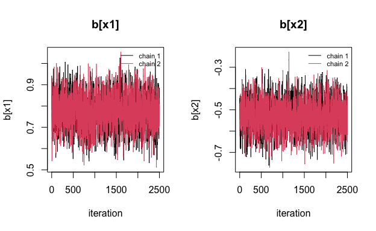

```r
traceplot(fit, block = "b")
```

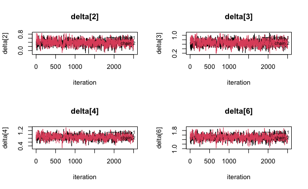

```r
traceplot(fit, block = "delta")
```

The same diagnostics are available programmatically, on any block, from the retained per-chain draws in `fit$chains`:

```r
b_chains <- lapply(fit$chains, function(ch) ch$b)
rhat(b_chains, rank = TRUE)
```

```
#>     x1     x2
#> 1.0016 0.9997
```

```r
ess(b_chains)
```

```
#>    bulk tail
#> x1 2160 3456
#> x2 2093 3419
```

```r
mcse(b_chains)
```

```
#>       x1       x2
#> 0.001664 0.001550
```

Two chains keep this vignette build manageable and permit between-chain checks; for a serious empirical run, four or more chains are often a better default. choicer offsets the RNG seed across chains but currently gives them the same data-driven initialization, so this is not an overdispersed-start diagnostic. Report the number of people, tasks per person and alternatives; all prior scales; HMNL acceptance rates; rank-normalized R-hat; bulk and tail ESS; MCSE; trace plots; and posterior-predictive shares. Show prior sensitivity for `W` and `sigma_d2`. For entry, defend why the entrant’s residual quality is exchangeable with incumbents rather than treating the posterior predictive as a data-free ASC.

## Did we recover the truth?

Because the data are simulated, we can line the posterior up against the generating parameters:

```r
recovery_table(fit, sim)
```

```
#> <choicer_recovery> model=choicer_hmnl level=0.95
#>       parameter   group    true estimate     se    bias rel_bias_pct z_vs_true
#>          <char>  <char>   <num>    <num>  <num>   <num>        <num>     <num>
#>  1:          x1    beta  0.8000   0.7751 0.0764 -0.0249      -3.1151   -0.3261
#>  2:          x2    beta -0.6000  -0.5268 0.0711  0.0732     -12.1994    1.0295
#>  3:       W[x1]       w  0.5000   0.6243 0.1350  0.1243      24.8514    0.9206
#>  4:       W[x2]       w  0.5000   0.4567 0.1010 -0.0433      -8.6646   -0.4288
#>  5: (Intercept)   theta  0.5000   0.8588 0.3397  0.3588      71.7510    1.0561
#>  6:          z1   theta -0.4000  -0.3036 0.5380  0.0964     -24.1059    0.1792
#>  7:     sigma_d sigma_d  0.5000   0.5611 0.2609  0.0611      12.2134    0.2341
#>  8:           1   delta  0.4846   0.5427 0.1292  0.0581      11.9956    0.4500
#>  9:           2   delta  0.3525   0.3828 0.1350  0.0303       8.5995    0.2246
#> 10:           3   delta  0.6180   0.6616 0.1293  0.0435       7.0439    0.3366
#> 11:           4   delta  0.9914   0.8638 0.1271 -0.1276     -12.8663   -1.0037
#> 12:           5   delta  0.3393   0.5069 0.1302  0.1676      49.4109    1.2876
```

[output cut: 16 more lines]

The population means `b`, the taste variances `diag(W)`, and the realized $\delta_j$ ladder recover tightly. Note the pattern in the `theta` and `sigma_d` rows: with only $J = 6$ alternatives, the mean-function regression of $\delta$ on $z$ has six observations, so those posteriors are wide and lean on the prior — more alternatives is what sharpens them. The *level* of $\delta$ has its own identification story: it is pinned by the outside-option share, so with a small outside share the level posterior is diffuse while the cross-alternative *contrasts* stay tight.

## Willingness to pay and predicted shares

Treating `x2` as the price-like attribute, `wtp()` forms the per-draw ratio of population-mean utility coefficients and summarizes its posterior — a median and quantile interval rather than a delta-method approximation, so the ratio’s skewness is carried through honestly:

```r
wtp(fit, price_var = "x2")
```

```
#>    attribute   wtp lower upper
#>       <char> <num> <num> <num>
#> 1:        x1 1.478 1.069  2.11
```

`predict()` integrates shares over both the taste distribution and the chain-1 posterior, returning posterior-predictive intervals (and the outside share):

```r
set.seed(7)
predict(fit, n_draws = 200)
```

```
#>    alternative   share       sd   lower   upper
#>         <char>   <num>    <num>   <num>   <num>
#> 1:           1 0.12513 0.010228 0.10667 0.14489
#> 2:           2 0.10865 0.009731 0.09117 0.12711
#> 3:           3 0.13512 0.009445 0.11704 0.15344
#> 4:           4 0.16652 0.009865 0.14848 0.18804
#> 5:           5 0.11752 0.008488 0.10271 0.13338
#> 6:           6 0.28834 0.015315 0.25597 0.31456
#> 7:   (outside) 0.05872 0.009962 0.03849 0.07785
```

A posterior-predictive check compares observed choice shares with the model’s predictive distribution — a first-pass reality check on fit:

```r
ppc_shares(fit, n_draws = 200)
```

```
#>    alternative observed predicted   lower   upper covered
#>         <char>    <num>     <num>   <num>   <num>  <lgcl>
#> 1:           1   0.1253   0.12501 0.10707 0.14527    TRUE
#> 2:           2   0.1073   0.10843 0.09232 0.12781    TRUE
#> 3:           3   0.1333   0.13487 0.11574 0.15454    TRUE
#> 4:           4   0.1680   0.16628 0.14821 0.18553    TRUE
#> 5:           5   0.1173   0.11757 0.09984 0.13274    TRUE
#> 6:           6   0.2907   0.28885 0.25556 0.31665    TRUE
#> 7:   (outside)   0.0580   0.05899 0.04182 0.08055    TRUE
```

Individual-level tastes are available too: `fit$beta_i` stores per-person posterior summaries (or full draws with `keep_beta_i = "draws"`), and `predict(fit, level = "individual")` conditions on them.

## A policy counterfactual

Cut the price `x2` of alternative 1 by 0.25 and re-predict — no refitting. Reusing the RNG seed makes the baseline and counterfactual share calculations use the same posterior and taste draws. This common-random-number pairing reduces Monte Carlo noise in the contrast; it does not make a finite-draw integral exact:

```r
cf <- sim$data
cf$x2[cf$alt == 1] <- cf$x2[cf$alt == 1] - 0.25

set.seed(7)
base_shares <- predict(fit, n_draws = 200)
set.seed(7)
cf_shares <- predict(fit, newdata = cf, n_draws = 200)

data.frame(
  alternative    = base_shares$alternative,
  baseline       = round(base_shares$share, 3),
  counterfactual = round(cf_shares$share, 3)
)
```

```
#>   alternative baseline counterfactual
#> 1           1    0.125          0.138
#> 2           2    0.109          0.107
#> 3           3    0.135          0.133
#> 4           4    0.167          0.164
#> 5           5    0.118          0.116
#> 6           6    0.288          0.284
#> 7   (outside)    0.059          0.058
```

The welfare change is the posterior of the compensating variation — the logsum difference divided by the marginal utility of income, draw by draw:

```r
set.seed(7)
cs <- consumer_surplus(fit, price_var = "x2", newdata = cf, n_draws = 200)
attr(cs, "cv")
```

```
#>   2.5%    50%  97.5%
#> -68.17  41.75 208.81
```

The three numbers are the lower quantile, posterior median, and upper quantile of the **sum** of compensating variation over the prediction tasks. Supply `weights = rep(1 / fit$nobs, fit$nobs)` for an equally weighted mean, or a substantively justified task-weight vector for another aggregate. The function does not normalize user-supplied weights.

Unlike a delta-method standard error, this interval carries posterior uncertainty in the logsum and in the population-mean marginal utility of income $-\bar\gamma_{price}$ used as the denominator. This is a population-mean money metric, not the posterior distribution of person-specific compensating variation when marginal utilities of income differ across people. The taste distribution still enters the integrated logsum, and for a lognormal price coordinate it also enters $\bar\gamma_{price} = \exp(b + W_{kk}/2)$. Report that aggregation choice explicitly in applications with price heterogeneity; an aggregate fixed-sign denominator does not by itself rule out individual price coefficients near or across zero. (`logsum()` and `consumer_surplus()` are available for the hierarchical *logit* only; the probit expected-maximum counterpart is on the roadmap.)

## An entry counterfactual

The distinctive payoff of the BLP-style alternative level. A model with fixed alternative-specific constants is silent about an alternative it has never seen — it has no ASC for the entrant and no principled way to invent one. Here the entrant is a draw from the estimated population of alternatives: given its characteristics $z_{\text{new}}$, each posterior draw assigns it $\delta_{\text{new}} \sim N(z_{\text{new}}'\theta_r,\; \sigma_{d,r}^2)$.

Add the entrant’s rows to the data — same layout, a new `alt` label, its `z1` value, `choice = 0` — and predict:

```r
entrant <- sim$data[sim$data$alt == 1, ]
entrant$alt <- 99L
entrant$z1 <- 0.4
entrant$choice <- 0L
entry_data <- rbind(sim$data, entrant)

set.seed(7)
predict(fit, newdata = entry_data, n_draws = 200)
```

```
#>    alternative   share      sd   lower   upper
#>         <char>   <num>   <num>   <num>   <num>
#> 1:           1 0.10003 0.01529 0.06639 0.12202
#> 2:           2 0.09367 0.01291 0.07470 0.11370
#> 3:           3 0.11648 0.01571 0.09082 0.13959
#> 4:           4 0.14408 0.01816 0.11948 0.16991
#> 5:           5 0.10138 0.01355 0.07956 0.12409
#> 6:           6 0.25022 0.03022 0.20973 0.29338
#> 7:          99 0.14399 0.09534 0.04630 0.29633
#> 8:   (outside) 0.05015 0.01025 0.03194 0.06843
```

The entrant takes share from every incumbent and from the outside good, and its credible interval is typically wider than the incumbents’ — appropriately so. The model knows the entrant’s observed characteristics but not its $\xi$, so the prediction integrates over $\xi_{\text{new}} \sim N(0, \sigma_d^2)$: the uncertainty about unobserved quality can be a dominant uncertainty about an entrant, and the posterior predictive exposes it rather than hiding it. The maintained assumption is exchangeability — the entrant’s unobserved quality is a draw from the same population as the incumbents’.

## Price endogeneity

If a price-like covariate is correlated with the unobserved quality $\xi_j$ — the classic demand-estimation concern — the estimates are exogenous only conditional on $Z$. The data preparations accept a control-function residual (`cf_residual_col`, Petrin and Train 2010): regress price on instruments outside the package, and pass the first-stage residual so it enters utility as an ordinary covariate. The package does not run the first stage, and posterior uncertainty does not propagate first-stage estimation error; joint Bayesian IV is on the roadmap.

## The probit sibling

`run_hmnprobit()` estimates the same two-level structure with iid normal utility shocks instead of extreme-value ones. The sampler is fully conjugate (Albert-Chib data augmentation — no Metropolis step, no acceptance rates to tune), and because it works in un-differenced utility space, unbalanced choice sets pose no problem. The probit has a free scale, handled by parameter expansion: a non-identified $\sigma^2$ chain wanders by design, and every reported quantity is normalized per draw, so all summaries are on the identified scale. Do not diagnose convergence from the wandering, unidentified raw `sigma2` chain alone; diagnose the normalized structural and predictive quantities that enter the economic conclusions.

```r
simp <- simulate_hmnp_data(N = 250, T = 5, J = 6, seed = 42)

set.seed(99)
fitp <- run_hmnprobit(
  data               = simp$data,
  id_col             = "task",
  alt_col            = "alt",
  choice_col         = "choice",
  covariate_cols     = c("x1", "x2"),
  person_col         = "pid",
  alt_covariate_cols = "z1",
  chains             = 2,
  mcmc               = list(R = 30000, burn = 5000, thin = 10)
)
```

```
#> MCMC run time 0h:0m:10s
```

```r
summary(fitp)
```

```
#> Hierarchical Bayesian Multinomial Probit (HMNP) model
#>
#> Population coefficients b (posterior):
#> Parameter        Mean         SD       2.5%     Median      97.5%
#> x1           0.838065   0.065126   0.714315   0.835738   0.972144
#> x2          -0.667914   0.062612  -0.791782  -0.667382  -0.546905
#>
#> Delta mean function theta (posterior):
#> Parameter          Mean         SD       2.5%     Median      97.5%
#> (Intercept)    0.739250   0.335655   0.034354   0.744141   1.398423
#> z1            -0.270462   0.565588  -1.382415  -0.278938   0.863512
#>
#> Alternative-effect variance (posterior):
#> Parameter        Mean         SD       2.5%     Median      97.5%
#> sigma_d^2    0.419601   0.584652   0.087334   0.279101   1.565759
#>
#> Raw shock variance (non-identified chain):
#> Parameter            Mean         SD       2.5%     Median      97.5%
#> sigma^2 (raw)    2.748469   1.118636   1.343773   2.480586   5.884916
#>
#> Quality ladder (delta = mean utility vs the outside option; xi = delta - z'theta):
#>  alternative delta_mean delta_sd xi_mean  xi_sd
#>            1     0.2803   0.1094 -0.2345 0.3734
#>            2     0.3280   0.1087 -0.1748 0.3907
#>            3     0.5738   0.1053 -0.2811 0.5084
#>            4     0.9771   0.1004  0.4166 0.3108
#>            5     0.2778   0.1097 -0.3848 0.2667
#>            6     1.3883   0.0966  0.6594 0.3142
#>
#> Convergence diagnostics (2 chains, 2500 draws each)
#> Block                R-hat  ESS_bulk  ESS_tail  MCSE(mean)
#> b[x1]                1.000      2714      4042      0.0013
#> b[x2]                1.000      2317      3524      0.0013
#> theta[(Intercept)]   1.000      3095      4557      0.0061
#> theta[z1]            1.000      5000      4760      0.0081
#> sigma_d^2            1.000      3946      4501      0.0096
#> sigma^2 (raw)^       1.056        24        31      0.3276
#> delta (J=6)         1.003*      576*     1430*         —
#> *worst: delta[1]
#> ^sigma^2 (raw) is the non-identified parameter-expansion scale (expected to not converge by design; excluded from the convergence-failure check).
#> Acceptance: conjugate — no acceptance step
#>
#> Respondents: 250  Choice situations: 1250  Alternatives: 6
#> Draws kept: 2500  Chains: 2
#> MCMC run time 0h:0m:10s
```

The identified probit coefficients live on a different scale from the logit’s. A common variance-matching rule notes that the EV1 shock has standard deviation $\pi/\sqrt{6} \approx 1.28$ against the probit’s 1, and therefore multiplies probit coefficients by $\pi/\sqrt{6}$ for a rough comparison. This is not an exact transformation: normal and Type-I extreme-value shocks have different shapes, and coefficients also need matched utility specifications and data:

```r
rbind(
  probit         = coef(fitp),
  "logit scale"  = coef(fitp) * pi / sqrt(6)
)
```

```
#>                 x1      x2
#> probit      0.8381 -0.6679
#> logit scale 1.0749 -0.8566
```

The `choicer_hb` post-estimation suite — `predict()` (probabilities by a deterministic fixed-node one-dimensional Gauss-Hermite approximation), `wtp()`, `elasticities()`, `diversion_ratios()`, `ppc_shares()`, `recovery_table()` — is available through the same interfaces on the probit fit. The exceptions are `logsum()` and `consumer_surplus()`, which are logit-only as noted above.

## Further reading

The full derivations — priors, the Gibbs sweeps, identification, and the implementation contract — are in the math companions: [hierarchical MNL](https://fpcordeiro.github.io/choicer/articles/hierarchical_mnl_math.html) and [hierarchical MNP](https://fpcordeiro.github.io/choicer/articles/hierarchical_mnp_math.html). For where these models sit among choicer’s estimators, see Choosing among choice models.

## References

Berry, S., Levinsohn, J. and Pakes, A. (1995). Automobile prices in market equilibrium. *Econometrica*, 63(4), 841-890.

Petrin, A. and Train, K. (2010). A control function approach to endogeneity in consumer choice models. *Journal of Marketing Research*, 47(1), 3-13.

Rossi, P. E., Allenby, G. M. and McCulloch, R. (2005). *Bayesian Statistics and Marketing*. Wiley.

Train, K. E. (2009). *Discrete Choice Methods with Simulation* (2nd ed.). Cambridge University Press.

Vehtari, A., Gelman, A., Simpson, D., Carpenter, B. and Bürkner, P.-C. (2021). Rank-normalization, folding, and localization: An improved R-hat for assessing convergence of MCMC. *Bayesian Analysis*, 16(2), 667-718.